# Projeto Airbnb Rio - Ferramenta de Previsão de Preço de Imóvel para pessoas comuns

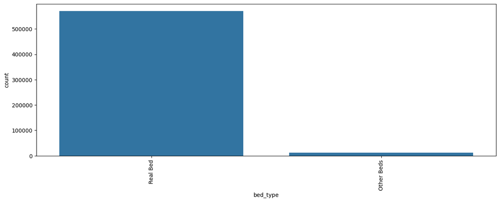

```python
for i in df_airbnb["bed_type"].value_counts().index:
    if df_airbnb["bed_type"].value_counts()[i] < 10000:
        df_airbnb.loc[df_airbnb["bed_type"]==i,"bed_type"] = "Other Beds"
valores_categoria(df_airbnb["bed_type"])
```

- cancellation_policy

```
cancellation_policy
flexible                       258096
strict_14_with_grace_period    200743
moderate                       113281
strict                           9696
super_strict_60                   135
super_strict_30                    32
Name: count, dtype: int64
```

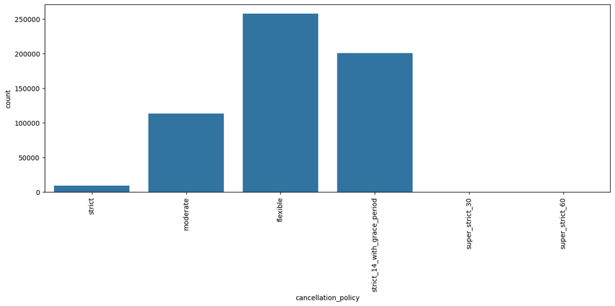

```python
print(df_airbnb["cancellation_policy"].value_counts())
valores_categoria(df_airbnb["cancellation_policy"])
```

[output not shown]

```
cancellation_policy
flexible                       258096
strict_14_with_grace_period    200743
moderate                       113281
strict                           9863
Name: count, dtype: int64
```

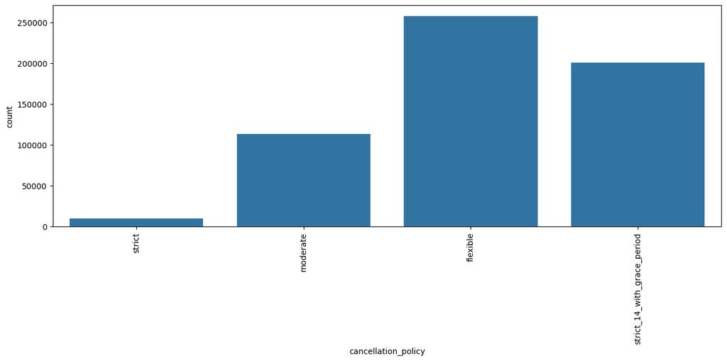

```python
for i in df_airbnb["cancellation_policy"].value_counts().index:
    if df_airbnb["cancellation_policy"].value_counts()[i] < 10000:
        df_airbnb.loc[df_airbnb["cancellation_policy"]==i,"cancellation_policy"] = "strict"

print(df_airbnb["cancellation_policy"].value_counts())
valores_categoria(df_airbnb["cancellation_policy"])
```

- amenities

como temos uma grande diversidade de amenities, sendo muito complexa sua analise, pois podem ser escritas de formas diferentes. Em nosso modelo iremos analisar apenas a quantidade

```python
df_airbnb = df_airbnb.reset_index(drop=True)
display(df_airbnb.loc[0, "amenities"])
```

```
'{TV,"Cable TV",Internet,Wifi,"Air conditioning",Kitchen,"Paid parking off premises","Smoking allowed",Doorman,Elevator,"Hot tub","Family/kid friendly","Suitable for events",Essentials,"24-hour check-in",Hangers,"Hair dryer",Iron,"Laptop friendly workspace","Self check-in","Front desk/doorperson","P…
```

```python
df_airbnb["amenities"] = df_airbnb["amenities"].apply(lambda value: value.count(",")+1)
display(df_airbnb.loc[0, "amenities"])
```

```
25
```

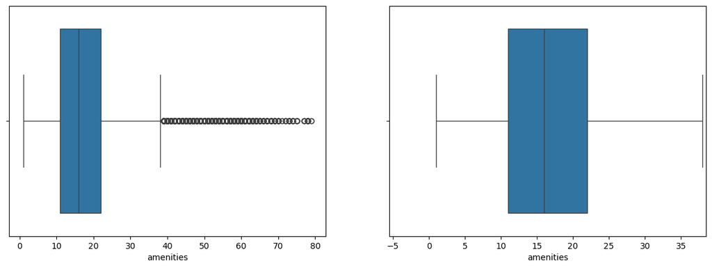

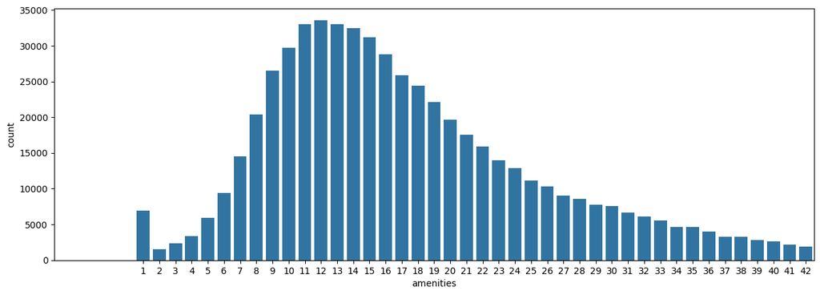

```python
plot_box(df_airbnb["amenities"])
barra(df_airbnb["amenities"])
```

```python
df_airbnb = remover_limites(df_airbnb, "amenities")
```

```
Removido 24343 linhas
```

Mapa latitude e longetude

```python
amostra = df_airbnb.sample(50000)
centro_mapa = {"lat":df_airbnb.latitude.mean(), "lon":df_airbnb.longitude.mean()}
mapa = px.density_mapbox(data_frame=amostra, lat="latitude", lon="longitude", z="price", radius=5, center=centro_mapa, zoom=10, mapbox_style="open-street-map")

mapa.show()
```

[output not shown]

### Encoding

- Features de True or False, serão substituidas por 1 e 0
- Features de Categoria, serão substituidas por variaveis dummies

```python
colunas = ["host_is_superhost", "instant_bookable", "is_business_travel_ready"]
df_code = df_airbnb.copy()
df_code[colunas] = np.where(df_code[colunas] == "t", 1, 0)
```

```python
colunas = ["cancellation_policy", "bed_type", "room_type", "property_type"]
df_code = pd.get_dummies(data=df_code, columns=colunas, dtype=int)
```

### Modelo de Previsão

- métricas de avaliação

```python
def avaliar_modelo(nome_modelo, y_teste, previsao):
    r2 = r2_score(y_teste, previsao)
    RSME = np.sqrt(mean_squared_error(y_teste, previsao))
    return f"Modelo {nome_modelo}\nR²: {r2:.2%}\nRSME: {RSME:.2f}\n"
```

- escolhendo os modelos que serão usados.
  1. Random Forest
  2. Linear Regression
  3. Extra Tree

```python
modelos = {"RandomForest": RandomForestRegressor(),
           "LinearRegression": LinearRegression(),
           "ExtraTrees":ExtraTreesRegressor()}

x = df_code.drop("price", axis=1)
y = df_code["price"]
```

- separando dados de treino e dados de teste + Treino do modelo

```python
x_train, x_test, y_train, y_test = train_test_split(x, y, random_state=10)

for nome_modelo, modelo in modelos.items():
    modelo.fit(x_train, y_train)
    previsao = modelo.predict(x_test)
    print(avaliar_modelo(nome_modelo, y_test, previsao))
```

```
Modelo RandomForest
R²: 97.24%
RSME: 44.06

Modelo LinearRegression
R²: 32.70%
RSME: 217.54

Modelo ExtraTrees
R²: 97.51%
RSME: 41.87
```

```python
for nome_modelo, modelo in modelos.items():
    previsao = modelo.predict(x_test)
    print(avaliar_modelo(nome_modelo, y_test, previsao))
```

```
Modelo RandomForest
R²: 97.24%
RSME: 44.06

Modelo LinearRegression
R²: 32.70%
RSME: 217.54

Modelo ExtraTrees
R²: 97.51%
RSME: 41.87
```

Escolhemos o modelo ExtraTress, pois ele teve o melhor resultado dentre os outros, também não houve grande diferença no tempo de treino e previsão, se compararmos com o RamdomForest, que teve resultados próximos.

Discartamos o modelo LinearRegression pela sua baixa pontuação

### Ajustes e Melhorias no Melhor Modelo

|  | 0 |
| --- | --- |
| bedrooms | 0.108452 |
| latitude | 0.103710 |
| longitude | 0.101571 |
| amenities | 0.088939 |
| extra_people | 0.088013 |
| accommodates | 0.079874 |
| bathrooms | 0.070628 |
| minimum_nights | 0.065347 |
| room_type_Entire home/apt | 0.063635 |
| beds | 0.052316 |
| host_listings_count | 0.039862 |
| instant_bookable | 0.021645 |
| cancellation_policy_flexible | 0.019325 |
| host_is_superhost | 0.013458 |
| property_type_Apartment | 0.012717 |
| cancellation_policy_moderate | 0.012065 |
| ano | 0.011259 |
| cancellation_policy_strict_14_with_grace_period | 0.007671 |
| property_type_House | 0.007067 |
| property_type_Condominium | 0.005089 |
| mes | 0.004697 |
| room_type_Private room | 0.003943 |
| bed_type_Other Beds | 0.002770 |
| bed_type_Real Bed | 0.002663 |
| property_type_Other | 0.002371 |
| property_type_Serviced apartment | 0.002232 |
| property_type_Loft | 0.002132 |
| room_type_Shared room | 0.001906 |
| property_type_Bed and breakfast | 0.001284 |
| property_type_Guesthouse | 0.000905 |
| cancellation_policy_strict | 0.000836 |
| property_type_Guest suite | 0.000667 |
| property_type_Hostel | 0.000636 |
| room_type_Hotel room | 0.000316 |
| is_business_travel_ready | 0.000000 |

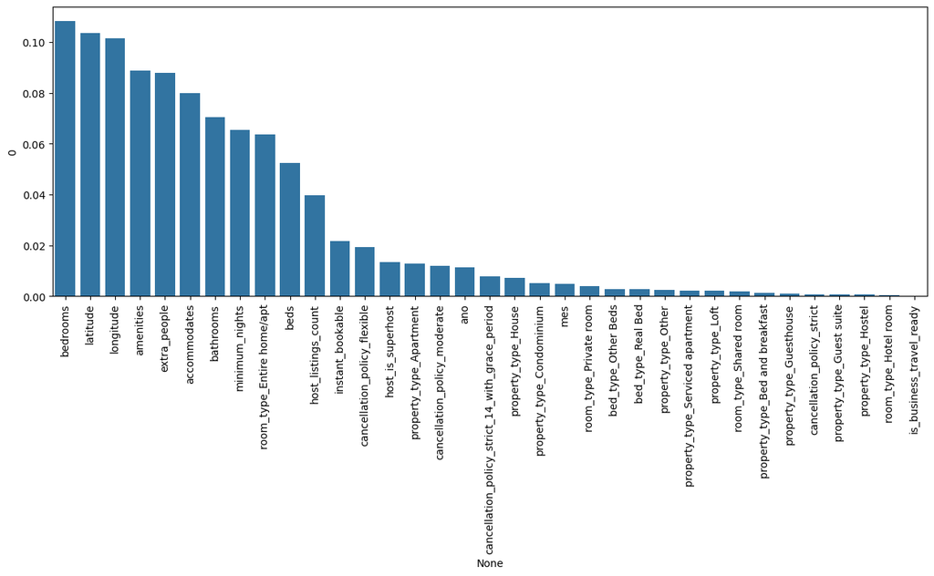

```python
df_features = pd.DataFrame(data=modelos["ExtraTrees"].feature_importances_, index=x_test.columns)
df_features = df_features.sort_values(by=0, ascending=False)

display(df_features)

plt.figure(figsize=(15,5))
sns.barplot(x=df_features.index, y=df_features[0])
plt.xticks(rotation=90)
plt.show()
```

A coluna is_business_travel_ready não tem importancia nenhuma em nosso modelo, então iremos remove-la

```python
teste_df = df_code.drop("is_business_travel_ready", axis=1)
x = teste_df.drop("price", axis=1)
y = teste_df["price"]

x_train, x_teste, y_train, y_test = train_test_split(x, y)
modelos["ExtraTrees"].fit(x_train, y_train)
previsao = modelos["ExtraTrees"].predict(x_teste)
print(avaliar_modelo("ExtraTree", y_test, previsao))
```

```
Modelo ExtraTree
R²: 97.47%
RSME: 42.01
```

Como teste, irei remover as colunas do bed_type, pois elas tem o mesmo nivel de importância

```python
teste_df = teste_df.drop([coluna for coluna in teste_df.columns if "bed_type" in coluna], axis=1)
x = teste_df.drop("price", axis=1)
y = teste_df["price"]

x_train, x_test, y_train, y_test = train_test_split(x, y)
modelos["ExtraTrees"].fit(x_train, y_train)
previsao = modelos["ExtraTrees"].predict(x_test)
print(avaliar_modelo("ExtraTrees", y_test, previsao))
```

```
Modelo ExtraTrees
R²: 97.48%
RSME: 41.91
```

# Deploy do modelo

```python
import joblib
x["price"] = y
x.to_csv("finalizada.csv", index=False)
joblib.dump(modelos["ExtraTrees"], "modelo.joblib")
```

```
['modelo.joblib']
```